# Diary for Bayesian Inference

Franz X. Mohr

2020-07-30

During the past years I realised that econometric analyis can be understood as a craft. You learn your basics at school from more or less motivated/talented professors and then you are sent out into wild, where you are confronted with real life challenges that differ from the stylised exmples you have become used to during your studies.

## Prior specification

### General issues

- **The prior precision matrix is the inverse of the variance matrix.** In Bayesian econometrics it is common to work with the precision matrix, since it is mathematically more convenient. Apart from algrebraic considerations you can express an uninformative prior by setting the respective value to zero. Otherwise you would have to work with infinite values, which is…well…just not good.
- **Be aware of potentially high mean values of intercepts.** If you work with time series data, which fluctuates aroung a mean of 100, this should be reflected in the prior of the intercept terms.
- **Be aware of the scales of your errors.** The prior variance of the error term should be reasonably proportional to the scale of the data. For example, when working with log-differenced growth rates of macroeconomic time series an increase of 1 percent is indicated by the value 0.01. However, a lot of economic data comes in a format, where 1 percent is indicated by a value of 1.
- **Don’t use too large priors for SSVS and BVS.** This might lead to a situation, where the algorithm cannot jump back to a state, where a certain variable should not be included in the model. See George et. al (2008) and Korobilis (2013).

### Common prior specifications for time series models

[output not shown]

## Computational issues

### Distribututions

#### Obtaining draws of inverse Wishart or inverse Gamma in R

```r
prior_df <- 100
prior_var <- 10

n <- 10000
```

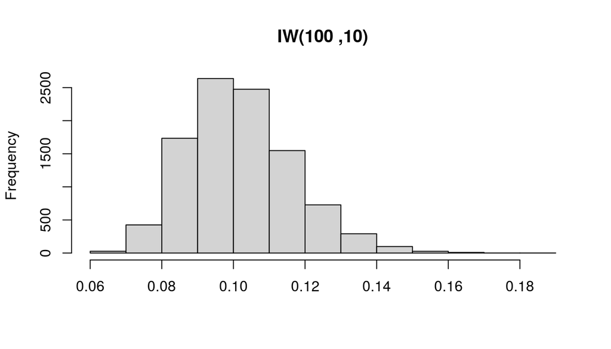

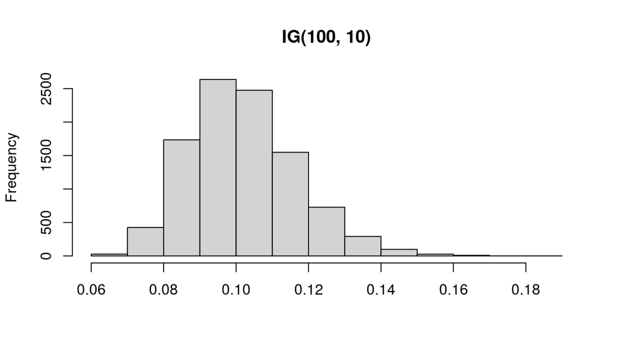

```r
# Draw from Wishart distribution
set.seed(1)# Reset random number generator
hist(1 / rWishart(n,
                  df = prior_df,
                  Sigma = diag(1 / prior_var, 1)),
     main = "IW(100 ,10)", xlab = NULL)

# Draw from Gamma distribution
set.seed(1) # Reset random number generator
hist(1 / rgamma(n,
                shape = prior_df / 2,
                scale = 1 / (prior_var / 2)),
     main = "IG(100, 10)", xlab = NULL)
```

## References

Chan, J., Koop, G., Poirier, D. J., & Tobias J. L. (2019). *Bayesian econometric methods* (2nd ed.). Cambridge: Cambridge University Press.

George, E. I., Sun, D., & Ni, S. (2008). Bayesian stochastic search for VAR model restrictions. *Journal of Econometrics, 142*(1), 553-580. https://doi.org/10.1016/j.jeconom.2007.08.017

Koop, G., & Korobilis, D. (2010). Bayesian multivariate time series methods for empirical macroeconomics. *Foundations and trends in econometrics, 3*(4), 267-358. https://dx.doi.org/10.1561/0800000013

Korobilis, D. (2013). VAR forecasting using Bayesian variable selection. *Journal of Applied Econometrics, 28*(2), 204-230.